# Stat 2131: Final Project

## Analysis of HIV Drug Resistance Data

The scientific goal is to determine which mutations of the Human Immunodeficiency Virus Type 1 (HIV-1) are associated with drug resistance. The data set, publicly available from the Stanford HIV Drug Resistance Database http://hivdb.stanford.edu/pages/published_analysis/genophenoPNAS2006/, was originally analyzed in (Rhee et al. 2006).

### Preparing the data

The data set consists of measurements for three classes of drugs: protease inhibitors (PIs), nucleoside reverse transcriptase (RT) inhibitors (NRTIs), and nonnucleoside RT inhibitors (NNRTIs). Protease and reverse transcriptase are two enzymes in HIV-1 that are crucial to the function of the virus. This data set seeks associations between mutations in the HIV-1 protease and drug resistance to different PI type drugs, and between mutations in the HIV-1 reverse transcriptase and drug resistance to different NRTI and NNRTI type drugs (The raw data are saved as `gene_df`).

In order to evaluate our results, we compare with the treatment-selected mutation panels created by (Rhee et al. 2005), which can be viewed as the ground true. These panels give lists of HIV-1 mutations appearing more frequently in patients who have previously been treated with PI, NRTI, or NNRTI type drugs, than in patients with no previous exposure to that drug type. Increased frequency of a mutation among patients treated with a certain drug type implies that the mutation confers resistance to that drug type (The raw data are saved as `tsm_df`).

To simplify the analysis, in this project we will confine our attention to the PI drugs.

```r
library(stringr)
drug_class = 'PI' # Possible drug types are 'PI', 'NRTI', and 'NNRTI'.
```

### Fetching and cleaning the data

First, we download the data and read it into data frames.

```r
base_url = 'http://hivdb.stanford.edu/_wrapper/pages/published_analysis/genophenoPNAS2006'
gene_url = paste(base_url, 'DATA', paste0(drug_class, '_DATA.txt'), sep='/')
tsm_url = paste(base_url, 'MUTATIONLISTS', 'NP_TSM', drug_class, sep='/')

gene_df = read.delim(gene_url, na.string = c('NA', ''), stringsAsFactors = FALSE)
tsm_df = read.delim(tsm_url, header = FALSE, stringsAsFactors = FALSE)
names(tsm_df) = c('Position', 'Mutations')
```

A small sample of the data is shown below.

```r
head(gene_df, n=6)
```

|  | IsolateName | PseudoName | MedlineID | APV | ATV | IDV | LPV | NFV | RTV | SQV | P1 | P2 | P3 | P4 | P5 | P6 | P7 | P8 | P9 | P10 | P11 | P12 | P13 | P14 | P15 | P16 | P17 | P18 | P19 | … |
| --- | --- | --- | --- | --- | --- | --- | --- | --- | --- | --- | --- | --- | --- | --- | --- | --- | --- | --- | --- | --- | --- | --- | --- | --- | --- | --- | --- | --- | --- | --- |
| 1 | CA10676 | CA622 | 10839657 | 2.3 | NA | 32.7 | NA | 23.4 | 51.6 | 37.8 | - | - | - | - | - | - | - | - | - | I | - | - | - | - | - | - | - | - | - | … |
| 2 | CA37880 | CA622 | 15995959 | 76.0 | NA | 131.0 | 200.0 | 50.0 | 200.0 | 156.0 | - | - | - | - | - | - | - | - | - | F | L | - | - | - | - | A | - | - | I | … |
| 3 | CA9984 | CA624 | 11897594 | 2.8 | NA | 12.0 | NA | 100.0 | 41.0 | 145.6 | - | - | - | - | - | - | - | - | - | - | - | - | V | - | - | - | - | - | - | … |
| 4 | CA17003 | CA628 | 15995959 | 6.5 | 9.2 | 2.1 | 5.3 | 5.0 | 36.0 | 13.0 | - | - | - | - | - | - | - | - | - | I | - | - | - | - | - | - | - | - | - | … |
| 5 | CA10670 | CA634 | 10839657 | 8.3 | NA | 100.0 | NA | 161.1 | 170.2 | 100.0 | - | - | - | - | - | - | - | - | - | I | - | - | - | - | - | - | - | - | - | … |
| 6 | CA42683 | CA634 | 15995959 | 82.0 | 75.0 | 400.0 | 400.0 | 91.0 | 400.0 | 400.0 | - | - | - | - | - | - | - | - | - | I | - | - | - | - | - | - | - | - | - | … |

```r
head(tsm_df, n=6)
```

|  | Position | Mutations |
| --- | --- | --- |
| 1 | 10 | F R |
| 2 | 11 | I |
| 3 | 20 | I T V |
| 4 | 23 | I |
| 5 | 24 | I |
| 6 | 30 | N |

In `tsm_df`, the variable `Position` denotes the position of the mutations that are associated with drug-resistance, while `Mutations` indicating the mutation type.

The gene data table has some rows with error flags or nonstandard mutation codes. For simplicity, we remove all such rows.

```r
# Returns rows for which every column matches the given regular expression.
grepl_rows <- function(pattern, df) {
  cell_matches = apply(df, c(1,2), function(x) grepl(pattern, x))
  apply(cell_matches, 1, all)
}

pos_start = which(names(gene_df) == 'P1')
pos_cols = seq.int(pos_start, ncol(gene_df))
valid_rows = grepl_rows('^(\\.|-|[A-Zid]+)$', gene_df[,pos_cols])
gene_df = gene_df[valid_rows,]
```

### Preparing the regression matrix

For example, in the sample for PI type drugs, three different mutations (A, C, and D) are observed at position 63 in the protease, and so three columns of $X$ (named P63.A, P63.C, and P63.D) indicate the presence or absence of each mutation at this position.

```r
# Flatten a matrix to a vector with names from concatenating row/column names.
flatten_matrix <- function(M, sep='.') {
  x <- c(M)
  names(x) <- c(outer(rownames(M), colnames(M),
                      function(...) paste(..., sep=sep)))
  x
}

# Construct preliminary design matrix.
muts = c(LETTERS, 'i', 'd')
X = outer(muts, as.matrix(gene_df[,pos_cols]), Vectorize(grepl))
X = aperm(X, c(2,3,1))
dimnames(X)[[3]] <- muts
X = t(apply(X, 1, flatten_matrix))
mode(X) <- 'numeric'

# Remove any mutation/position pairs that never appear in the data.
X = X[,colSums(X) != 0]

# Extract response matrix.
Y = gene_df[,4:(pos_start-1)]
```

An excerpt of the design matrix is shown below. By construction, every column contains at least one 1, but the matrix is still quite sparse with the relative frequency of 1’s being about 0.025.

```r
library(DT)
datatable(data.frame(X)[1:10, ], options = list(scrollX=T, pageLength = 10))
```

|  | P4.A | P12.A | P13.A | P16.A | P20.A | P22.A | P28.A | P37.A | P51.A | P54.A | P63.A | P71.A | P73.A | P74.A | P79.A | P82.A | P84.A | P91.A | P37.C | P63.C | P67.C | P73.C | P82.C | P84.C | P91.C | P95.C | P4.D | P12.D | P25.D | … |
| --- | --- | --- | --- | --- | --- | --- | --- | --- | --- | --- | --- | --- | --- | --- | --- | --- | --- | --- | --- | --- | --- | --- | --- | --- | --- | --- | --- | --- | --- | --- |
| 1 | 0 | 0 | 0 | 0 | 0 | 0 | 0 | 0 | 0 | 0 | 0 | 0 | 0 | 0 | 0 | 0 | 0 | 0 | 0 | 0 | 0 | 0 | 0 | 0 | 0 | 0 | 0 | 0 | 0 | … |
| 2 | 0 | 0 | 0 | 1 | 0 | 0 | 0 | 0 | 0 | 0 | 0 | 0 | 0 | 0 | 0 | 0 | 0 | 0 | 0 | 0 | 0 | 0 | 0 | 0 | 0 | 0 | 0 | 0 | 0 | … |
| 3 | 0 | 0 | 0 | 0 | 0 | 0 | 0 | 0 | 0 | 0 | 0 | 1 | 0 | 0 | 0 | 0 | 0 | 0 | 0 | 0 | 0 | 0 | 0 | 0 | 0 | 0 | 0 | 0 | 0 | … |
| 4 | 0 | 0 | 0 | 0 | 0 | 0 | 0 | 0 | 0 | 0 | 0 | 0 | 0 | 0 | 0 | 1 | 0 | 0 | 0 | 0 | 0 | 0 | 0 | 0 | 0 | 0 | 0 | 0 | 0 | … |
| 5 | 0 | 0 | 0 | 0 | 0 | 0 | 0 | 0 | 0 | 0 | 0 | 0 | 0 | 0 | 0 | 1 | 0 | 0 | 0 | 0 | 0 | 0 | 0 | 0 | 0 | 0 | 0 | 0 | 0 | … |
| 6 | 0 | 0 | 0 | 0 | 0 | 0 | 0 | 0 | 0 | 0 | 0 | 0 | 0 | 0 | 0 | 1 | 0 | 0 | 0 | 0 | 0 | 0 | 0 | 0 | 0 | 0 | 0 | 0 | 0 | … |
| 7 | 0 | 0 | 0 | 0 | 0 | 0 | 0 | 0 | 0 | 0 | 0 | 0 | 0 | 0 | 0 | 1 | 0 | 0 | 0 | 0 | 0 | 0 | 0 | 0 | 0 | 0 | 0 | 0 | 0 | … |
| 8 | 0 | 0 | 0 | 0 | 0 | 0 | 0 | 1 | 0 | 0 | 0 | 0 | 0 | 0 | 0 | 0 | 0 | 0 | 0 | 0 | 0 | 0 | 0 | 0 | 0 | 0 | 0 | 0 | 0 | … |
| 9 | 0 | 0 | 0 | 1 | 0 | 0 | 0 | 0 | 0 | 0 | 0 | 0 | 0 | 0 | 0 | 0 | 0 | 0 | 0 | 0 | 0 | 0 | 0 | 0 | 0 | 0 | 0 | 0 | 0 | … |
| 10 | 0 | 0 | 0 | 0 | 0 | 0 | 0 | 0 | 0 | 0 | 0 | 0 | 0 | 0 | 0 | 1 | 0 | 0 | 0 | 0 | 0 | 0 | 0 | 0 | 0 | 0 | 0 | 0 | 0 | … |

```r
dim(X)
```

```
## [1] 846 361
```

The response matrix looks like:

```r
head(Y, n=6)
```

|  | APV | ATV | IDV | LPV | NFV | RTV | SQV |
| --- | --- | --- | --- | --- | --- | --- | --- |
| 1 | 2.3 | NA | 32.7 | NA | 23.4 | 51.6 | 37.8 |
| 2 | 76.0 | NA | 131.0 | 200.0 | 50.0 | 200.0 | 156.0 |
| 3 | 2.8 | NA | 12.0 | NA | 100.0 | 41.0 | 145.6 |
| 4 | 6.5 | 9.2 | 2.1 | 5.3 | 5.0 | 36.0 | 13.0 |
| 5 | 8.3 | NA | 100.0 | NA | 161.1 | 170.2 | 100.0 |
| 6 | 82.0 | 75.0 | 400.0 | 400.0 | 91.0 | 400.0 | 400.0 |

```r
dim(Y)
```

```
## [1] 846   7
```

There are 7 PI-type drugs: APV, ATV, IDV, LPV, NFV, RTV, and SQV.

### Selecting drug-resistance-associated mutations

In this step, you need to impose a linear regression model, and use the method we discussed in lecture to select mutations that may associated with drug-resistance. For 7 PI-type drugs, you need to run a separate analysis for each drug.

Notice that there are some missing values.

Before selecting associated mutations, we need to perform some final pre-processing steps. We remove rows with missing values (which vary from drug to drug) and we then further reduce the design matrix by removing predictor columns for mutations that do not appear at least three times in the sample. Finally, for identifiability, we remove any columns that are duplicates (i.e. two mutations that appear only in tandem, and therefore we cannot distinguish between their effects on the response).

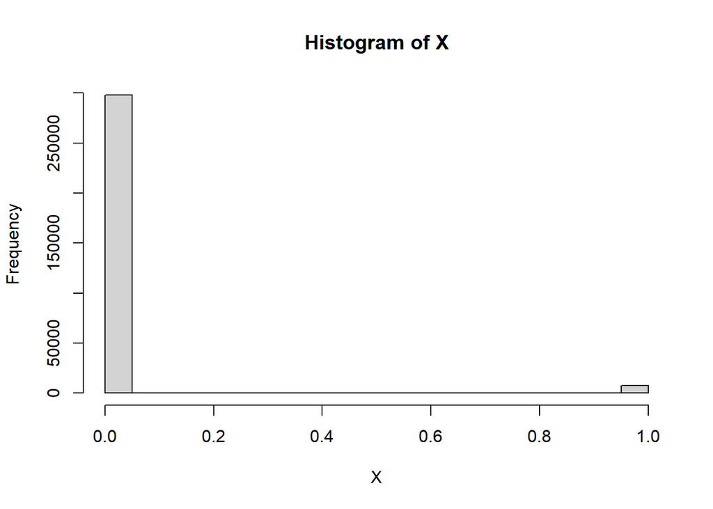

```r
hist(X)
```

```r
selection <- function (X, y, alpha) {
  # Remove patients with missing measurements.
  missing = is.na(y)
  y = y[!missing]
  X = X[!missing,]

  # Remove predictors that appear less than 3 times.
  X = X[,colSums(X) >= 3]

  # Remove duplicate predictors.
  X = X[,colSums(abs(cor(X)-1) < 1e-4) == 1]

  # Based on an appropriate linear regression model
  # Select the mutations that may associated with drug-resistance
  #######################
  #######################
  full_model <- lm(y ~ ., data = as.data.frame(X))
  model_selection <- step(full_model, direction = "both", k=2) # k=2 means use AIC as criteria, direction = both means use both back and forward step-wise selection methods, = forward means use forward step-wise selection

 # return(summary(model_selection))

  #######################
  #######################
}

alpha = 0.05 # the nominal FWER
# results = lapply(Y, function(y) selection(X, y, alpha))
```

```r
results = lapply(Y, function(y) selection(X, y, alpha))
```

```r
as.integer(str_extract(as.data.frame(row.names(as.data.frame(coef(results$APV)))[-1])$`row.names(as.data.frame(coef(results$APV)))[-1]`,"[0-9]+"))
```

```
##  [1] 71 84 84 37 58 60 61 70 33 66 82 37 61 69 11 15 19 32 36 66 77 69 11 54 66
## [26] 71 72 93 48 54 19 74 34 91 20 43 63 73 82 10 15 20 36 47 50 64 66 71 76 84
## [51] 85 89
```

### Evaluating the results

```r
#Extract Position from ground true df.
ground_true_position <- tsm_df$Position


#Extract 7 drugs positions used for fitting model
APV_Position <- as.integer(str_extract(as.data.frame(row.names(as.data.frame(coef(results$APV)))[-1])$`row.names(as.data.frame(coef(results$APV)))[-1]`,"[0-9]+"))

ATV_Position <- as.integer(str_extract(as.data.frame(row.names(as.data.frame(coef(results$ATV)))[-1])$`row.names(as.data.frame(coef(results$ATV)))[-1]`,"[0-9]+"))

IDV_Position <- as.integer(str_extract(as.data.frame(row.names(as.data.frame(coef(results$IDV)))[-1])$`row.names(as.data.frame(coef(results$IDV)))[-1]`,"[0-9]+"))

LPV_Position <- as.integer(str_extract(as.data.frame(row.names(as.data.frame(coef(results$LPV)))[-1])$`row.names(as.data.frame(coef(results$LPV)))[-1]`,"[0-9]+"))

NFV_Position <- as.integer(str_extract(as.data.frame(row.names(as.data.frame(coef(results$NFV)))[-1])$`row.names(as.data.frame(coef(results$NFV)))[-1]`,"[0-9]+"))

RTV_Position <- as.integer(str_extract(as.data.frame(row.names(as.data.frame(coef(results$RTV)))[-1])$`row.names(as.data.frame(coef(results$RTV)))[-1]`,"[0-9]+"))

SQV_Position <- as.integer(str_extract(as.data.frame(row.names(as.data.frame(coef(results$SQV)))[-1])$`row.names(as.data.frame(coef(results$SQV)))[-1]`,"[0-9]+"))
```

```r
# define a function to compute match rate
eva_drug <- function (vector1,vector_true) {
 compare_drug <- intersect(vector1, vector_true)
 match_rate <- length(compare_drug)/length(vector_true)
 return(match_rate)
}
```

```r
# Evaluate the result by comparing it to the ground true
#######################
#######################
eva_drug(APV_Position,ground_true_position);eva_drug(ATV_Position,ground_true_position);eva_drug(IDV_Position,ground_true_position);
```

```
## [1] 0.6176471
```

```
## [1] 0.7352941
```

```
## [1] 0.6764706
```

```r
eva_drug(LPV_Position,ground_true_position);eva_drug(NFV_Position,ground_true_position);eva_drug(RTV_Position,ground_true_position);eva_drug(SQV_Position,ground_true_position)
```

```
## [1] 0.8823529
```

```
## [1] 0.7058824
```

```
## [1] 0.8529412
```

```
## [1] 0.6176471
```

```r
#######################
#######################
```

### Building a linear model for prediction

In this part, we consider building a linear model for predicting drug resistance to APV. We extract all mutations at those positions provided by the file `tsm_df`.

```r
get_name<-function(x){return(outer(x["Position"], unlist(strsplit(x["Mutations"], split =" ")), function(...) paste(..., sep=".") ))}
mutation_name <- paste("P", unlist(apply(tsm_df, 1, get_name)), sep="")
col_index <- which( colnames(X) %in% mutation_name)
candidate_X <- X[, col_index]
```

```r
#Extract APV as response variable and check the dimension of response variable and predict variables before final pre-processing steps
APV_y <- Y$APV
APV_y <- as.data.frame(APV_y)
dim(APV_y);dim(candidate_X)
```

```
## [1] 846   1
```

```
## [1] 846  58
```

```r
# Run final pre-processing steps
library(caret)
library(MASS)

 # Remove patients with missing measurements.
  missing = is.na(APV_y)
  APV_y = APV_y[!missing]
  candidate_X = candidate_X[!missing,]
```

```r
APV_y <- as.data.frame(APV_y)
```

```r
  # Remove predictors that appear less than 3 times.
  candidate_X = candidate_X[,colSums(candidate_X) >= 3]

  # Remove duplicate predictors.
  candidate_X = candidate_X[,colSums(abs(cor(candidate_X)-1) < 1e-4) == 1]
```

```r
#Check the dimension of response variable and predict variables after final pre-processing steps
dim(APV_y);dim(candidate_X)
```

```
## [1] 767   1
```

```
## [1] 767  55
```

```r
# Split "candidate_X" and response into training set and test set

set.seed(1199)
data_index <- createDataPartition(APV_y$APV_y, p = 0.7, list = FALSE)
train_X <- candidate_X[data_index, ]
train_y <- APV_y[data_index]
test_X <- candidate_X[-data_index, ]
test_y <- APV_y[-data_index]
```

```r
#test_y <- as.numeric(test_y[,1])
```

We need to build a model by using candidate explanatory variables provided by `candidate_X` above. Build a model for prediction with an appropriate model selection criterion, which can be either AIC, BIC, or leave-one-out cross-validation error. Use an appropriate approach to evaluate the model you build. For example, you may split the data into two subsets, and use one for model building and the other for model evaluation.

```r
# Model selection and prediction
#######################
#######################
APV_model <- lm(train_y ~ ., data = as.data.frame(train_X))
APV_selection <- step(APV_model, direction = "both", k=2)
#######################
#######################
```

```r
summary(APV_selection)
```

```
##
## Call:
## lm(formula = train_y ~ P79.A + P84.A + P84.C + P58.E + P33.F +
##     P66.F + P82.F + P11.I + P24.I + P32.I + P54.L + P48.M + P82.S +
##     P20.T + P82.T + P47.V + P50.V + P76.V + P84.V + P89.V, data = as.data.frame(train_X))
##
## Residuals:
##     Min      1Q  Median      3Q     Max
## -56.634  -1.179   1.559   2.309 164.573
##
## Coefficients:
##             Estimate Std. Error t value Pr(>|t|)
## (Intercept)  -0.9593     0.8176  -1.173 0.241217
## P79.A        16.9244     9.6084   1.761 0.078758 .
## P84.A        69.4361     6.4118  10.829  < 2e-16 ***
## P84.C        21.3842     6.1224   3.493 0.000519 ***
## P58.E         6.1650     3.1660   1.947 0.052043 .
## P33.F        19.0473     2.6751   7.120 3.62e-12 ***
## P66.F        11.8377     6.3451   1.866 0.062655 .
## P82.F        10.8031     4.4522   2.426 0.015587 *
## P11.I        34.3260     6.1179   5.611 3.28e-08 ***
## P24.I         4.9056     3.1123   1.576 0.115586
## P32.I        17.7588     3.7949   4.680 3.67e-06 ***
## P54.L         7.2267     4.4986   1.606 0.108792
## P48.M        23.1317     9.3532   2.473 0.013714 *
## P82.S       -15.9965    11.2001  -1.428 0.153823
## P20.T        22.5507     4.1846   5.389 1.08e-07 ***
## P82.T        -5.3958     3.2836  -1.643 0.100938
## P47.V        17.7889     5.0897   3.495 0.000515 ***
## P50.V        22.2564     5.6266   3.956 8.70e-05 ***
## P76.V        19.1502     3.7726   5.076 5.38e-07 ***
## P84.V         8.0125     1.9120   4.191 3.27e-05 ***
## P89.V        45.2350     5.7850   7.819 2.99e-14 ***
## ---
## Signif. codes:  0 '***' 0.001 '**' 0.01 '*' 0.05 '.' 0.1 ' ' 1
##
## Residual standard error: 15.37 on 518 degrees of freedom
## Multiple R-squared:  0.5902, Adjusted R-squared:  0.5744
## F-statistic:  37.3 on 20 and 518 DF,  p-value: < 2.2e-16
```

```r
predict_APV <- predict(APV_selection, as.data.frame(test_X))
mse <- mean((predict_APV - test_y)^2)
r_squared <- cor(predict_APV, test_y)^2
mse;r_squared
```

```
## [1] 907.591
```

```
## [1] 0.346602
```

```r
APV_model_new <- lm(train_y ~  P84.A + P84.C + P33.F + P11.I + P32.I + P20.T + P47.V + P50.V + P76.V + P84.V + P89.V, data = as.data.frame(train_X))
predict_APV_new <- predict(APV_model_new, as.data.frame(test_X))
mse_new <- mean((predict_APV_new - test_y)^2)
r_squared_new <- cor(predict_APV_new, test_y)^2
mse_new;r_squared_new
```

[output not shown]

### References

Rhee, Soo-Yon, W Jeffrey Fessel, Andrew R Zolopa, Leo Hurley, Tommy Liu, Jonathan Taylor, Dong Phuong Nguyen, et al. 2005. “HIV-1 Protease and Reverse-Transcriptase Mutations: correlations with Antiretroviral Therapy in Subtype B Isolates and Implications for Drug-Resistance Surveillance.” *Journal of Infectious Diseases 192 (3). Oxford University Press: 456–65*.

Rhee, Soo-Yon, Jonathan Taylor, Gauhar Wadhera, Asa Ben-Hur, Douglas L Brutlag, and Robert W Shafer. 2006. “Genotypic Predictors of Human Immunodeficiency Virus Type 1 Drug Resistance.” *Proceedings of the National Academy of Sciences 103 (46). National Academy of Sciences: 17355–60*.